# Group Project Report - Do Upfront Conditional Cash Transfers Always Lead to Higher School Attendance

Jialu Zhang Julie Shi Ning Yang Sofia Aljure Zixuan Wang

## Part 1: Research Proposal

### Executive Summary / Abstract

**Authors (Names and Percentages)**: Sofia Aljure 100%

To: Colombia’s Ministry of Education From: Group 7, Research Design Class, Applied Analytics Master of Science, at Columbia University Date: December 9th, 2021

We study the way in which two different payment structures of the conditional cash transfer program influence and impact school attendance by low-income children in Bogota, Colombia. We base this research on the two predominant payment mechanisms used in the CCT programs: rolling out the cash transfers before and after compliance verification. We seek to prove that transferring the conditional cash after compliance with the program has been verified, increases secondary school attendance, and improves educational outcomes of low-income children in Colombia.

Problem Statement Conditional Cash Transfers have been proven to increase educational outcomes in third-world countries throughout the Latin American region, primarily Colombia and Mexico. However, there has been little to no attention shed on how the different payment structures of these programs influence and impact their outcome.

Study Objectives - The following research seeks to determine the way in which different payment structures influence and impact the outcome of conditional cash transfer programs in Bogota, Colombia. - Provide insights to government officials regarding specific payment structures on the conditional cash transfer programs, showcasing opportunities for improvement that might lead to a higher program success rate.

Research Design To carry out this research 600 low-income students were selected from 10 random high schools in Bogotá, Colombia. Their families voluntarily consented to participate. The researchers controlled for confounding variables such as gender, income level, children per household, and residential area. Students were divided equally into control and treatment groups, receiving the conditional cash transfers before and after compliance verification respectively. They would be monitored during the duration of the program to ensure their compliance with the program’s rules and expectations. Data of the beneficiary students was obtained from the secondary schools in Colombia, and local government agencies.

The measurement of the student’s attendance was done by calculating the average attendance rate during the duration of the program, and then performing a difference in proportions test to understand if this is statistically significantly higher for students who receive the conditional cash transfer after compliance verification, than those students who receive it before.

### Statement of the Problem

**Authors (Names and Percentages)**: Sofia Aljure 100%

Education is a key enabler to escape poverty and enable upward social mobility. The United Nations has established as one of its Sustainability Goals, to ensure “inclusive and equitable education for all by 2030.” Even though major progress has been made, in 2018, 260 million children were still out of school. This proves that despite the importance and critical role of education, governments and academics still need further understanding on factors that influence whether and for how long children are formally educated (United Nations, Student Resources, 2020).

Conditional Cash Transfers (CCTs) are one of the most prevalent social assistant programs in the developing world. Their objective is to reduce poverty while improving health and education outcomes in vulnerable communities. CCTs originated in Latin America and the Caribbean (LAC) during the mid-nineties as a result of reforms to poverty reduction programs. The poverty reduction programs were mostly based on tax breaks and consumption subsidies, which generated significant price distortions, proving to be extremely inefficient. Conditional Cash Transfers were designed as a response to these failed attempts to alleviate and break the poverty cycle. The theory that underpins these programs is to alleviate poverty by supporting the consumption of the poorest households through direct, conditioned, and recurring cash transfers. These conditionality schemes focus at promoting investments in children’s human capital, by requiring compliance with child health, nutrition, school enrollment and attendance (Ibarrán, Pablo, et al 2017.).

There has been extensive literature that studies and evaluates the impact of Conditional Cash Transfers in different operational respects. It has been proven to increase educational outcomes in countries like Colombia and Mexico. However, there has been little attention shed on the importance and influence of the different payment mechanisms used by the cash transfer programs. Currently there are two predominant payment mechanisms used in the CCT programs. The first one consists in rolling out the cash transfers before compliance verification. This method is currently used in Bogota, Colombia and works by rolling out the payments every two months, before verifying compliance. The government entities verify compliance at the end of the period and if a family does not comply, they will not be qualified for re-enrollment.

The second method consists of rolling out conditional cash transfers after compliance verification. This is a structure commonly used in Mexico, under which the payments are rolled in a 1-2-3 structure, comprising 3 two months periods. In the first four months, families fulfill co-responsibilities and schools report attendance to government entities. In the third period payment is made to the families, reflecting their compliance for the last four months. (Ibarrán, Pablo, et al.2011).

The present paper will focus on the design of a research that seeks to determine the way in which different payment structures influence and impact the outcome of conditional cash transfer programs in Bogota, Colombia. To do this, the impact of changing the payment structure of the CCT programs that are currently run in the city will be evaluated, studying how issuing cash transfers after verifying compliance impacts the program’s outcome.

### Research Questions and Hypotheses

**Authors (Names and Percentages)**: Julie Shi 100%

This study will investigate the secondary education attendance rate in Bogota, Colombia, under different Conditional Cash Transfer designs.

Research Question: Do CCTs that are paid every two months after compliance verification result in a higher secondary education attendance rate, than the CCTs that are paid every two months upfront in Bogota, Colombia?

The population metric is the average secondary school attendance rate across Bogota, Colombia during the academic year 2021-2022.

Null hypothesis: CCTs that are paid after compliance verification does not lead to a higher average secondary school attendance rate across Bogota, Colombia.

In mathematical terms, the null hypothesis can be expressed as: μ_1 - μ_0 ≤ 0, where μ_1 is defined as the average secondary school attendance rate under CCTs paid after compliance verification, and μ_0 is defined as the average secondary school attendance rate under CCTs paid upfront.

Alternative hypothesis: CCTs that are paid after compliance verification leads to a higher average secondary school attendance rate across Bogota, Colombia.

In mathematical terms, the alternative hypothesis can be expressed as: μ_1 - μ_0 > 0, where μ_1 is defined as the average secondary school attendance rate under CCTs paid after compliance verification, and μ_0 is defined as the average secondary school attendance rate under CCTs paid upfront.

### Importance of the Study

**Authors (Names and Percentages)**: Ning Yang(50%), Zixuan Wang(50%)

It is already known a lot about the impact of the current CCT program on various results. However, little is known about the impact under different CCT design features. In this paper, an important element of program design is paid attention to - the timeline of payment.The project will focus on the design of a research that seeks to determine the way in which different payment structures influence and impact the educational outcome of conditional cash transfer programs in Bogota, Colombia. To do this, the impact of changing the payment structure of the CCT programs that are currently run in the city will be evaluated, studying how issuing cash transfers after verifying compliance impacts the program’s outcome. Through the research, it can help to determine what kind of payment methods would encourage students’ education, and better improve the attendance rate of secondary education in Bogotá, Colombia, while avoiding waste of resources.

The CCT plan has multiple goals, such as reallocating resources and promoting investments in human capital. Increasing school attendance will help to increase the likelihood of achieving these goals with a better payment structure. Comparing the impact of different payment structures on school attendance will help the government improve the design of the CCT program, and more effectively promote the education for poor children, and maximize the effectiveness of CCTs.

### Literature Review

**Authors (Names and Percentages)**: Jialu Zhang(40%), Julie Shi(30%), Ning Yang(30%)

Conditional cash transfers are among the most relevant and fastest-growing social assistance programs in low and middle-income countries (Garcia & Saavedra, 2012). Much of the research on CCTs document the short term educational impacts on outcomes that include school enrollment, attendance, and dropout rates.

The CCTs program in Colombia, also referred to as MÁS FAMILIAS EN ACCIÓN (MFA), was first rolled out in 2000 as a temporary program to improve health and education outcomes among low-income families (Inter-American Development Bank, 2021). Since then, multiple types of research and studies have been conducted on the payment mechanisms and how different payment structure designs affect students’ attendance, enrollment, and graduation outcomes among the secondary schools in Bogota, Colombia. Currently, Colombia’s cash transfers are paid bi-monthly, conditional on at least 80% of school attendance (Inter-American Development Bank, 2021).

In 2005, the study “Improving the Design of Conditional Transfer Programs: Evidence from a Randomized Education Experiment in Colombia” randomized three different payment structures within the Conditional Cash Transfer Programs (Barrera et al., 2011). Under the first payment structure, referred to as the “savings” treatment, the participants had to save one-third of a conditional bimonthly cash transfer until the following academic year. The second structure provided participants with a standard CCT payment scheme in which they received a bi-monthly cash transfer dependent on school attendance and enrollment. Finally, under the third treatment, which was called the “tertiary” treatment, participants not only received a bimonthly conditional cash transfer but were also given an additional monetary incentive for secondary graduation and tertiary enrollment. This study showed that changing the structure of the conditional cash transfer programs generated an increase in enrollment rate without decreasing the attendance rate. Additionally, the savings and tertiary treatment showed a significant increase in the matriculation rate of tertiary institutions, with a rise of 9.4% and 48.9%, respectively.

Other researches on CCTs’ effect on school enrollment in developing countries was also conducted; one discovered the impact of payment frequency on the CCTs outcomes (Juan Esteban Saavedra et al., 2012). The research used the samples of 19 programs in 15 countries, and fifty-two percent of the programs pay educational transfers on a monthly basis, while over forty percent pay transfers less frequently, either bi-monthly, quarterly or bi-annually. It found that the low frequency of payment (monthly vs less regularly) is positively associated with the size of primary and secondary enrollment. Like Colombia, Mexico has also adopted the CCT program, changed its name to Prospera Social Inclusion Program in 2014, and updated the payment structure and timing in the program, according to the Inter-American Development Bank. Mexico adopted a 1-2-3 calendar to complete the process of compliance, verification, and payment, which requires a total of 3 two-month periods. It means that in the first two months, the school and family jointly inspect the attendance rate of students. In the middle two months, the school and the health centre report the attendance rate to Prospera. In the last two months, Prospera distributed subsidies based on attendance. (Inter-American Development Bank, 2021). It also found that Mexico’s secondary education enrollment rate was higher than in Colombia since 2014 (The World Bank,2020).

There is much research on CCTs, little known about the impact of CCTs’ payment timing structure on Colombia’s educational outcomes. This study aims to fill the gap and evaluate the relationship between the secondary school attendance rate and the different payment timing structures.

### Research Plan

**Authors (Names and Percentages)**: Julie Shi 100%

This experiment will cooperate with 10 randomly selected secondary high schools in Colombia’s capital city Bogota, and the secondary high schools will help with implementing the experiment and collecting the data needed. Data of beneficiary students’ attendance performance will be obtained for the academic year 2021-2022. The detailed plans are described in the following sections below.

#### Population of Interest

**Authors (Names and Percentages)**: Julie Shi 100%

The Population of Interest is all secondary school students from Grade 7 to Grade 12 who come from families below the poverty line in Bogota. The poverty line is defined as US$5.5/day per capita income per World Bank data (World Bank, 2020).

#### Sample Selection

**Authors (Names and Percentages)**: Julie Shi 100%

Secondary high schools in the area of Bogota will be randomly selected, and the same number of students who come from families below the poverty line will be chosen randomly for each school. An equal number of students from each grade from Grade 7 to 12 will again be randomly selected within each school. Then half the number of the selected students from each grade will be assigned to form the control group, and the other half will be assigned to the treatment group.

The treatment group will participate in the payment structure that is the same as Mexico’s CCTs program, while the control group will stay in Colombia’s existing CCTs program. Mexico has a CCTs program in which students are paid followed by their attendance every two months. In contrast, the existing CCTs program in Colombia gives students money every two months upfront and then suspends the money when insufficient attendance occurs. The attendance of all students from each secondary high school will then be recorded throughout the academic year from 2021 to 2022. At the end of the academic year, the average attendance rate for both the control group and treatment group will be compared.

The above randomized controlled methodology emphasizes the importance of randomization by first drawing high schools followed by drawing students from each school. The sample students are expected to have a similar family income background with the population, and also cover the full range of high school Grade years. In addition, it limits the differences between the treatment and control groups by controlling the number of students from each grade to the same amount.

#### Sample Size

**Authors (Names and Percentages)**: Julie Shi 100%

The total sample size for this experimental study has been defined as 600. Statistical power analysis was performed to determine the optimal sample size for this experiment. It was assumed that this experiment has a 90% chance of finding a difference in attendance rates when there is one between the two groups, and an average attendance rate of 10% improvement is considered meaningful. Therefore, the effect size has been determined as approximately 0.23 using the proportional power analysis method, under the scenario that the average attendance rate would increase from 70% to 80% with treatment group CCT payment structure.

The sample size for each group has been calculated as 318 students, and the final sample size has been rounded to 300 students in each group, which leads to a total sample size of 600.

```r
library(pwr)
h = ES.h(p1 = 0.8, p2 = 0.7)
h
```

```
[1] 0.2319843
```

```r
pwr.2p.test(h = h,
           sig.level = 0.05,
           power = 0.90,
           alternative = "greater")
```

```
     Difference of proportion power calculation for binomial distribution (arcsine transformation)

              h = 0.2319843
              n = 318.2599
      sig.level = 0.05
          power = 0.9
    alternative = greater

NOTE: same sample sizes
```

#### Operational Procedures

**Authors (Names and Percentages)**: Julie Shi 100%

The business question for this research design is to explore the optimal CCT payment structure that leads to a higher high school attendance rate. The experiment will be based on randomly selected participants from randomly selected high schools in Bogota, Colombia, with Grades ranging from 7 to 12 and an approximately equal number of males and females. There are 600 participants needed for the experiment from 10 schools. Therefore, each school will recruit 60 students with 10 students from each grade. The experiment will last for 10 months, from September 2021 to June 2022.

As the students from the family below the poverty line are already receiving the CCT benefits, the control group already has available participants for the experiment. The recruiting process for participants will focus more on changing the payment structure for students selected to be in the treatment group.

The principal of each selected high school will delegate the head of each grade to randomly choose 10 students who have been receiving CCT benefits to participate in this experiment. The head of each Grade will then divide the 10 selected students into two groups, 5 students will continue receiving the CCT benefits as standard, while the other 5 students will be notified about the change of CCT structure. The head of each Grade will monitor both groups of students for their attendance, however, the participants will not be notified that their attendance has been recorded.

The attendance for each participant will be recorded on a daily basis throughout the academic year 2021-2022. At the end of the experiment, the attendance rate of each student will be calculated, and the average attendance rate for each group will be compared.

### Brief Schedule

**Authors (Names and Percentages)**: Jialu Zhang(40%), Ning Yang(30%), Zixuan Wang(30%)

The brief schedule of this experiment study is shown in the below table. The entire study is expected to last from July 2021 to August 2022.

The preparation phases will start two months ahead of the experiment, the Experiment Set-up and Training, and Experiment Participants Enrollment within the preparation phase are both expected to last for two weeks. Contingency of two weeks has been given to each of these two phases if any delays shall occur.

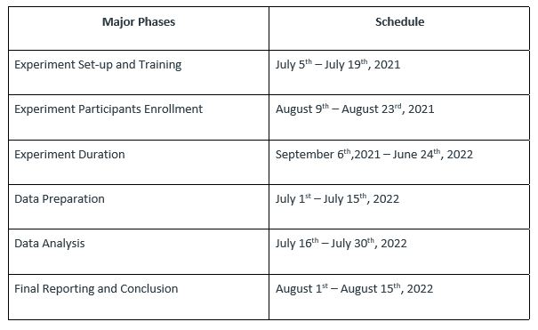

```r
knitr::include_graphics("Table1.jpg")
```

#### Data Collection

**Authors (Names and Percentages)**: Julie Shi (50%) Sofia Aljure (50%)

The independent variables in this study are the two different payment structures of the conditional cash transfer program. This experiment focuses on two different payment structures, which differ on the timing of the cash transfers: being paid before and after compliance verification. The control group will receive the cash transfers before compliance verification, while the treatment group will receive them after the compliance is verified. The dependent variable on this study is the rate of children’s school attendance.

In addition to the attendance information, there are other variables that need to be collected and controlled for this study. The research group believes that gender, age, family composition, and family income could be potential confounding variables that may impact the results, and the data of these variables will be collected. The gender of the children will likely impact their school attendance. There are strong social and cultural factors that will probably impact whether a family prioritizes school attendance for boys rather than girls, regardless of whether they are receiving conditional cash transfers or not. Therefore, this experiment will include an equal number of girls and boys in each group. The age of the children and family composition is likely to also impact children’s school attendance. Low-income families with multiple children are more likely to prioritize school attendance for children who they believe have a more “promising” future, while they rely on the others for extra help around the house, or as an additional source of income. Age will also probably influence attendance, as families are likely to prioritize school attendance for children who have yet to begin school, and have a clear path ahead of them, rather than those children who might have missed several years of school in the past, and their school attendance is just not a priority anymore. Other potential confounding variables for this study can be found when analyzing the mechanism that makes it easier / harder for children to get to school. Some of them include, transportation, location of their homes, and additional subsidies that the families might be receiving. Families that are receiving subsidies for transportation and live close to schools are more likely to prioritize attendance for their children than those who live further away and have to budget for transportation as an out-of-pocket expense. Finally, the student ID and year of Grade of participants will also be recorded as part of the dataset.

#### Data Security

**Authors (Names and Percentages)**: Julie Shi (50%) Sofia Aljure (50%)

This research involves human subjects. Therefore, everyone involved in it will receive appropriate training ensuring that this study is carried out in an ethical way that complies with the law. Since this study aims at improving educational outcomes of low-income children in Colombia, we will collaborate with local government agencies ensuring that we are able to carry out this research in a way that complies with local laws and regulations. Additionally, the privacy and security of the students will be protected, by identifying the children who will participate in the experiment with their student ID, and not their personal name. Finally, the data collected at the end of the experiment will only be available to the Grade Heads in high schools and the research team on a need-to-know basis.

#### Outcomes (Dependent Variables)

**Authors (Names and Percentages)**: Ning Yang(50%), Zixuan Wang(50%)

In this research, the dependent variable is the average attendance rate of the treatment group and control group. The attendance performance of 300 students in each group will be recorded throughout the school year from 2021 to 2022, at the end of academic year, the attendance rate of each student will be calculated, and the average attendance rate of all students in each group will then be calculated and compared to help determine which payment method will result in a higher attendance rate. The dependent variable, average attendance rate in each group, will be the outcome of the study which can reflect which CCT payment structure results in a higher average secondary school attendance across the selected high schools.

#### Treatments (Independent Variables)

**Authors (Names and Percentages)**: Ning Yang(50%), Zixuan Wang(50%)

In this research, the independent variable is theCCT payment timing. As mentioned in the previous sections, there are two different payment timings. One of them is the method currently used in Mexico where students get paid every two months followed by school attendance. The other is Colombia’s existing CCTs plan to give students an advance payment every two months, and then suspend the payment when there is insufficient attendance.

The research is to test which average attendance rate is higher under these two different payment methods.Cooperating with 10 random schools in Bogota, Colombia, 60 students from each school will be randomly selected. The sample size is 600 middle school students from Bogotá to test different results under different payment time structures. The attendance rate of 60 students in each middle school will then be recorded throughout the school year from 2021 to 2022 to help determine which payment method will result in a higher attendance rate at the end of the 2022 school year. Based on the results, whether different payment methods in the experiment have an impact on the attendance can be determined.

#### Other Variables

**Authors (Names and Percentages)**: Ning Yang(40%), Zixuan Wang(40%), Julie Shi (20%)

In addition to dependent variables and independent variables, this research will also include other variables in the below list. Trying to gain a holistic view of the participants’ information and potential confounding variables in the study is important to avoid bias.

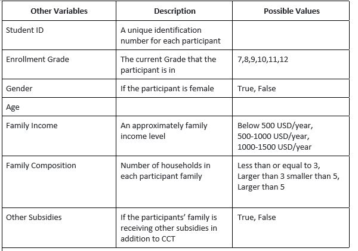

```r
knitr::include_graphics("Table2.jpg")
```

### Statistical Analysis Plan

**Authors (Names and Percentages)**: Ning Yang(50%), Zixuan Wang(50%)

The collected data includes attendance rates of 300 participating students who receive CCT every two months after compliance verification, and attendance rates of 300 participating students who receive CCT upfront.

The question being answered is whether there is a significant (or only random) difference in the average attendance rate under CCTs paid after compliance verification vs. under CCTs paid upfront. To perform this test, both samples must be normally distributed. First, whether the two sets of data are normally distributed should be tested. When a normal distribution is assumed, one can specify a level of probability (p value, 5%) as a criterion for acceptance.

Secondly, if the two data sets follow a normal distribution, the study will use two sample t-test to detect the difference in attendance rate of the two populations. The assumptions of t test - simple random sample, normal distribution, and the homogeneity of variance are satisfied. The outcome of the two sample t-test produces the p-value which is then compared against a value obtained from a critical value table. This comparison helps to determine the effect of chance alone on the difference, and whether the difference is outside that chance range. The t-test questions whether the attendance difference between the two groups represents a true difference in the research or if it is possibly a meaningless random difference.

### Limitations and Uncertainties

**Authors (Names and Percentages)**: Ning Yang(40%), Zixuan Wang(40%), Julie Shi (20%)

Firstly, the design and implementation of the entire experiment are demanding, and the experiment also requires the establishment of relationships with the participating high schools and may require additional resources from local government agencies.

Secondly, the researchers are constrained by the scope and budget of the experiment, therefore, the experiment is only conducted in Bogota, and the research result will not be representative enough to represent the attendance rate of students across other regions of Colombia. The analysis results may lead to varying degrees of influence on the experimental results inferred to the whole.

Moreover, the number of people studied in the experiment is large, and the time required for the experiment to collect data is long, so the accuracy of the data might be compromised, which will affect the results of the experiment.

In addition, as identified in previous sections, there are other variables that may become potential confounding variables. If not considered, the results may not reflect the actual relationship between the independent and dependent variables, and the accuracy of the research might be impacted.

## Part 2: Simulated Studies

**Authors (Names and Percentages)**: Ning Yang(50%), Zixuan Wang(50%)

### Research Question 1:

#### Scenario 1: No Effect

**Authors (Names and Percentages)**: Ning Yang(50%), Zixuan Wang(50%)

##### Simulation

```r
# One experiment
n <- 600
library(data.table)
library(DT)
RNGversion(vstr = 3.6)
set.seed(seed = 1000 )

bp.dat<-data.table(Group = c(rep.int(x="Treatment",times=n/2),rep.int(x="Control",times=n/2)))
bp.dat[Group == "Control", BP := round(x = rnorm(n = .N, mean = 0.7, sd = 0.1), digits = 2)]
bp.dat[Group == "Treatment", BP := round(x = rnorm(n = .N, mean = 0.7, sd = 0.1), digits = 2)]
datatable(data=bp.dat)
```

|  | Group | BP |
| --- | --- | --- |
| 1 | Treatment | 0.76 |
| 2 | Treatment | 0.59 |
| 3 | Treatment | 0.7 |
| 4 | Treatment | 0.69 |
| 5 | Treatment | 0.8 |
| 6 | Treatment | 0.64 |
| 7 | Treatment | 0.52 |
| 8 | Treatment | 0.59 |
| 9 | Treatment | 0.61 |
| 10 | Treatment | 0.6 |

[output cut: 590 more lines]

```r
# 1000 experiments

B<-1000
n <- 600
library(data.table)
library(DT)
RNGversion(vstr = 3.6)
set.seed(seed = 1000 )
Experiment<-1:B
Group<-c(rep.int(x="Treatment",times=n/2),rep.int(x="Control",times=n/2))
sim.dat2 <-as.data.table(expand.grid(Experiment=Experiment,Group=Group))
setorderv(x=sim.dat2,cols=c("Experiment","Group"),order=c(1,1))
sim.dat2[Group == "Control", BP := round(x = rnorm(n = .N, mean = 0.7, sd = 0.1), digits = 2)]
sim.dat2[Group == "Treatment", BP := round(x = rnorm(n = .N, mean = 0.7, sd = 0.1), digits = 2)]
dim(sim.dat2)
```

```
[1] 600000      3
```

##### Analysis

```r
analyze.experiment<-function(the.dat){
  require(data.table)
  setDT(the.dat)
  the.test<-t.test(x = the.dat[Group == "Treatment",  BP],
                   y = the.dat[Group == "Control", BP], alternative = "greater")
  the.effect <- the.test$estimate[1] - the.test$estimate[2]
  upper.bound <- the.test$conf.int[2]
  p <- the.test$p.value
  result <- data.table(effect = the.effect, upper_ci = upper.bound,  p = p)
  return(result)
}

exp.results2<-sim.dat2[,analyze.experiment(the.dat=.SD),
                     keyby="Experiment"]
exp.results2
```

```
      Experiment        effect upper_ci          p
   1:          1 -3.333333e-05      Inf 0.50169099
   2:          2  1.160000e-02      Inf 0.07004802
   3:          3  7.000000e-03      Inf 0.20286232
   4:          4  1.633333e-03      Inf 0.42113135
   5:          5 -7.666667e-03      Inf 0.83264429
  ---
 996:        996  3.166667e-03      Inf 0.34744978
 997:        997  1.423333e-02      Inf 0.04008833
 998:        998 -1.170000e-02      Inf 0.92218951
 999:        999 -9.766667e-03      Inf 0.86901209
1000:       1000 -1.393333e-02      Inf 0.95911734
```

```r
DT::datatable(data=round(x=exp.results2[1:100,],digits=3),
              rownames=F)
```

| Experiment | effect | upper_ci | p |
| --- | --- | --- | --- |
| 1 | 0 |  | 0.502 |
| 2 | 0.012 |  | 0.07 |
| 3 | 0.007 |  | 0.203 |
| 4 | 0.002 |  | 0.421 |
| 5 | -0.008 |  | 0.833 |
| 6 | 0.012 |  | 0.079 |
| 7 | -0.01 |  | 0.889 |
| 8 | -0.016 |  | 0.97 |
| 9 | 0.01 |  | 0.113 |
| 10 | 0.003 |  | 0.343 |

[output cut: 90 more lines]

```r
exp.results2[,mean(p<0.05)]
```

```
[1] 0.046
```

```r
exp.results2[,summary(effect)]
```

```
      Min.    1st Qu.     Median       Mean    3rd Qu.       Max.
-0.0256000 -0.0058750 -0.0002833 -0.0003814  0.0049333  0.0281333
```

```r
exp.results2[,summary(upper_ci)]
```

```
   Min. 1st Qu.  Median    Mean 3rd Qu.    Max.
    Inf     Inf     Inf     Inf     Inf     Inf
```

#### Scenario 2: An Expected Effect

**Authors (Names and Percentages)**: Ning Yang(50%), Zixuan Wang(50%)

First, we determined the sample size, and we randomly and equally assigned the samples to the control and treatment groups. And then, We created outcome variable control for treatment (mean = 0.8) and control (mean = 0.7) both are normally distributed. SD of 0.1. Finally, we set the test function to obtain the effect, upper confidence interval and p-value.

##### Simulation

```r
#1 experiment
n <- 600
library(data.table)
library(DT)
RNGversion(vstr = 3.6)
set.seed(seed = 1000 )

bp.dat<-data.table(Group = c(rep.int(x="Treatment",times=n/2),rep.int(x="Control",times=n/2)))
bp.dat[Group == "Control", BP := round(x = rnorm(n = .N, mean = 0.7, sd = 0.1), digits = 2)]
bp.dat[Group == "Treatment", BP := round(x = rnorm(n = .N, mean = 0.8, sd = 0.1), digits = 2)]
datatable(data=bp.dat)
```

|  | Group | BP |
| --- | --- | --- |
| 1 | Treatment | 0.86 |
| 2 | Treatment | 0.69 |
| 3 | Treatment | 0.8 |
| 4 | Treatment | 0.79 |
| 5 | Treatment | 0.9 |
| 6 | Treatment | 0.74 |
| 7 | Treatment | 0.62 |
| 8 | Treatment | 0.69 |
| 9 | Treatment | 0.71 |
| 10 | Treatment | 0.7 |

[output cut: 590 more lines]

```r
#1000 experiment
B<-1000
n <- 600
library(data.table)
library(DT)
RNGversion(vstr = 3.6)
set.seed(seed = 1000 )
Experiment<-1:B
Group<-c(rep.int(x="Treatment",times=n/2),rep.int(x="Control",times=n/2))
sim.dat <-as.data.table(expand.grid(Experiment=Experiment,Group=Group))
setorderv(x=sim.dat,cols=c("Experiment","Group"),order=c(1,1))
sim.dat[Group == "Control", BP := round(x = rnorm(n = .N, mean = 0.7, sd = 0.1), digits = 2)]
sim.dat[Group == "Treatment", BP := round(x = rnorm(n = .N, mean = 0.8, sd = 0.1), digits = 2)]
dim(sim.dat)
```

```
[1] 600000      3
```

##### Analysis

```r
#create function
analyze.experiment<-function(the.dat){
  require(data.table)
  setDT(the.dat)
  the.test<-t.test(x = the.dat[Group == "Treatment",  BP],
                   y = the.dat[Group == "Control", BP], alternative = "less")
the.effect <- the.test$estimate[1] - the.test$estimate[2]
    upper.bound <- the.test$conf.int[2]
    p <- the.test$p.value
    result <- data.table(effect = the.effect, upper_ci = upper.bound,  p = p)
    return(result)
}
#analyze 1000 experiments
exp.results<-sim.dat[,analyze.experiment(the.dat=.SD),
                     keyby="Experiment"]
exp.results
```

```
      Experiment     effect   upper_ci p
   1:          1 0.09996667 0.11291652 1
   2:          2 0.11160000 0.12453487 1
   3:          3 0.10700000 0.12085990 1
   4:          4 0.10163333 0.11514888 1
   5:          5 0.09233333 0.10541548 1
  ---
 996:        996 0.10316667 0.11646114 1
 997:        997 0.11423333 0.12761207 1
 998:        998 0.08830000 0.10185706 1
 999:        999 0.09023333 0.10456339 1
1000:       1000 0.08606667 0.09923227 1
```

```r
DT::datatable(data=round(x=exp.results[1:100,],digits=3),
              rownames=F)
```

| Experiment | effect | upper_ci | p |
| --- | --- | --- | --- |
| 1 | 0.1 | 0.113 | 1 |
| 2 | 0.112 | 0.125 | 1 |
| 3 | 0.107 | 0.121 | 1 |
| 4 | 0.102 | 0.115 | 1 |
| 5 | 0.092 | 0.105 | 1 |
| 6 | 0.112 | 0.125 | 1 |
| 7 | 0.09 | 0.103 | 1 |
| 8 | 0.084 | 0.098 | 1 |
| 9 | 0.11 | 0.123 | 1 |
| 10 | 0.104 | 0.118 | 1 |

[output cut: 90 more lines]

```r
exp.results[,mean(p<0.05)]
```

```
[1] 0
```

```r
exp.results[,summary(effect)]
```

```
   Min. 1st Qu.  Median    Mean 3rd Qu.    Max.
0.07440 0.09413 0.09972 0.09962 0.10493 0.12813
```

```r
exp.results[,summary(upper_ci)]
```

```
   Min. 1st Qu.  Median    Mean 3rd Qu.    Max.
 0.0880  0.1075  0.1132  0.1131  0.1184  0.1416
```

[figure not shown]

```r
knitr::include_graphics("Table3.jpg")
```

## References

**Authors (Names and Percentages)**: Jialu Zhang 70%, Sofia Aljure 10%, Ning Yang 10%, Julie Shi 10%

Baird, S., Ferreira, F., Ozler, B., & Woolcock, M. (2014), “Conditional, unconditional and everything in between: a systematic review of the effects of cash transfer programmes on schooling outcomes” Retrieved from https://www.tandfonline.com/doi/abs/10.1080/19439342.2014.890362

Deon,F., Norbert,Schady.u (September 2011), “Does more cash in conditional cash transfer programs always lead to larger impacts on school attendance?,Journal of Development Economics,Volume 96, Issue 1,2011,Pages 150-157,ISSN 0304-3878.” Retrieved from https://www.sciencedirect.com/science/article/pii/S0304387810000507

Felipe Barrera-Osorio, Marianne,B, Leigh L. Linden, Francisco Perez-Calle.(2011), “Improving the Design of Conditional Transfer Programs: Evidence from a Randomized Education Experiment in Colombia.” American Economic Journal: Applied Economics, 3 (2): 167-95. DOI: 10.1257/app.3.2.167” Retrieved from https://www.povertyactionlab.org/sites/default/files/research-paper/Conditional%20Cash%20Transfers%20April%2011.pdf

Ibarrán, Pablo, et al. (2017) “How Conditional Cash Transfers Work” Retrieved from https://doi.org/10.18235/0000746. Inter-American Development Bank (2021). Retrieved from https://www.iadb.org/en/toolkit/conditional-cash-transfer-programs/mexico-prospera?country=21453

Juan Esteban Saavedra & Sandra Garcia, (2012). “Impacts of Conditional Cash Transfer Programs on Educational Outcomes in Developing Countries A Meta-analysis,” Working Papers WR-921-1, RAND Corporation. Retrieved from https://citeseerx.ist.psu.edu/viewdoc/download?doi=10.1.1.232.7148&rep=rep1&type=pdf

The World Bank (2020). Retrieved from https://databank.worldbank.org/data/download/poverty/987B9C90-CB9F-4D93-AE8C-750588BF00QA/AM2020/Global_POVEQ_COL.pdf

The World Bank (2020). Retrieved from https://data.worldbank.org/indicator/SE.SEC.ENRR?locations=CO-MX&name_desc=true

United Nations, “Student Resources – United Nations Sustainable Development” Retrieved from https://www.un.org/sustainabledevelopment/student-resources/.